# Topic 1-07: Get GO/KEGG gene sets for other organisms

Zuguang Gu z.gu@dkfz.de

2025-03-02

Besides those well-studied organisms, there are also resources for less well-studies organisms, mainly for KEGG and GO gene sets.

## KEGG pathways

KEGG pathway supports a huge number of organisms, just try different organism code:

```r
read.table(url("https://rest.kegg.jp/list/pathway/hsa"), sep = "\t")
read.table(url("https://rest.kegg.jp/list/pathway/ptr"), sep = "\t")
read.table(url("https://rest.kegg.jp/list/pathway/pps"), sep = "\t")
read.table(url("https://rest.kegg.jp/list/pathway/ggo"), sep = "\t")
read.table(url("https://rest.kegg.jp/list/pathway/pon"), sep = "\t")
...
```

## BioMartGOGeneSets

The **BioMartGOGeneSets** package has compiled GO gene sets for > 700 organisms using [the biomart web service](https://www.ensembl.org/info/data/biomart/index.html) (with the **biomaRt** package.

To obtain the gene sets, use the function `getBioMartGOGeneSets()`. Also you need to provide the “dataset”. The name of the dataset can be obtained by `supportedOrganisms()` or from https://bioconductor.org/packages/devel/data/annotation/vignettes/BioMartGOGeneSets/inst/doc/supported_organisms.html. Let’s get GO gene sets for mouse.

```r
library(BioMartGOGeneSets)
lt = getBioMartGOGeneSets("mmusculus_gene_ensembl")
length(lt)
```

```
## [1] 15791
```

```r
lt[1]
```

```
## $`GO:0000002`
##  [1] "ENSMUSG00000019699" "ENSMUSG00000028982" "ENSMUSG00000022615"
##  [4] "ENSMUSG00000039264" "ENSMUSG00000030557" "ENSMUSG00000030879"
##  [7] "ENSMUSG00000032449" "ENSMUSG00000038084" "ENSMUSG00000022889"
## [10] "ENSMUSG00000041064" "ENSMUSG00000033845" "ENSMUSG00000107283"
## [13] "ENSMUSG00000027424" "ENSMUSG00000036875" "ENSMUSG00000038225"
## [16] "ENSMUSG00000022292" "ENSMUSG00000004069" "ENSMUSG00000039176"
## [19] "ENSMUSG00000025209" "ENSMUSG00000029911" "ENSMUSG00000020718"
## [22] "ENSMUSG00000030978" "ENSMUSG00000026496" "ENSMUSG00000028893"
## [25] "ENSMUSG00000002814" "ENSMUSG00000026365" "ENSMUSG00000015337"
## [28] "ENSMUSG00000034203" "ENSMUSG00000059552" "ENSMUSG00000055660"
## [31] "ENSMUSG00000028455" "ENSMUSG00000030314" "ENSMUSG00000020697"
## [34] "ENSMUSG00000036923" "ENSMUSG00000032633" "ENSMUSG00000029167"
```

The variable `lt` is a list of vectors where each vector corresponds to a GO gene set with Ensembl IDs as gene identifiers.

You can try the following command and see what will be printed:

```r
lt = getBioMartGOGeneSets("mouse")
```

In `getBioMartGOGeneSets()`, argument `as_table` can be set to `TRUE`, then the function returns a data frame.

```r
tb = getBioMartGOGeneSets("mmusculus_gene_ensembl", as_table = TRUE)
head(tb)
```

```
##   go_geneset       ensembl_gene
## 1 GO:0000002 ENSMUSG00000019699
## 2 GO:0000002 ENSMUSG00000028982
## 3 GO:0000002 ENSMUSG00000022615
## 4 GO:0000002 ENSMUSG00000039264
## 5 GO:0000002 ENSMUSG00000030557
## 6 GO:0000002 ENSMUSG00000030879
```

Argument `ontology` controls which category of GO gene sets. Possible values should be `"BP"`, `"CC"` and `"MF"`.

```r
getBioMartGOGeneSets("mmusculus_gene_ensembl", ontology = "BP") # the default one
getBioMartGOGeneSets("mmusculus_gene_ensembl", ontology = "CC")
getBioMartGOGeneSets("mmusculus_gene_ensembl", ontology = "MF")
```

Last, argument `gene_id_type` can be set to `"entrez_gene"` or `"gene_symbol"`, then genes in the gene sets are in Entrez IDs or gene symbols. Note this depends on specific organisms, that not every organism supports Entrez IDs or gene symbols.

```r
lt = getBioMartGOGeneSets("mmusculus_gene_ensembl", gene_id_type = "entrez_gene")
lt[1]
```

```
## $`GO:0000002`
##  [1] "23797"  "70556"  "72962"  "83408"  "17258"  "27397"  "192287" "74143"
##  [9] "27393"  "208084" "27395"  "17527"  "74528"  "327762" "408022" "382985"
## [17] "83945"  "18975"  "226153" "381760" "50776"  "20133"  "11545"  "230784"
## [25] "21975"  "12628"  "13804"  "72170"  "22059"  "76781"  "66592"  "74244"
## [33] "16882"  "216021" "216805" "19017"
```

```r
lt = getBioMartGOGeneSets("mmusculus_gene_ensembl", gene_id_type = "gene_symbol")
lt[1]
```

```
## $`GO:0000002`
##  [1] "Akt3"     "Slc25a33" "Tymp"     "Gimap3"   "Mef2a"    "Mrpl17"
##  [7] "Slc25a36" "Opa1"     "Mrpl39"   "Pif1"     "Mrpl15"   "Mpv17"
## [13] "Mgme1"    "Dna2"     "Primpol"  "Rrm2b"    "Dnaja3"   "Polg"
## [19] "Twnk"     "Ssbp1"    "Polg2"    "Rrm1"     "Parp1"    "Sesn2"
## [25] "Top3a"    "Cfh"      "Endog"    "Chchd4"   "Trp53"    "Mettl4"
## [31] "Stoml2"   "Atg7"     "Lig3"     "Stox1"    "Flcn"     "Ppargc1a"
```

## OrgDb objects

Biocondutor core team maintaines **org.*.db** packages for 18 organisms

| Package | Organism | Package | Organism |
| --- | --- | --- | --- |
| `org.Hs.eg.db` | Human | `org.Ss.eg.db` | Pig |
| `org.Mm.eg.db` | Mouse | `org.Gg.eg.db` | Chicken |
| `org.Rn.eg.db` | Rat | `org.Mmu.eg.db` | Rhesus monkey |
| `org.Dm.eg.db` | Fruit fly | `org.Cf.eg.db` | Canine |
| `org.At.tair.db` | Arabidopsis | `org.EcK12.eg.db` | E coli strain K12 |
| `org.Sc.sgd.db` | Yeast | `org.Xl.eg.db` | African clawed frog |
| `org.Dr.eg.db` | Zebrafish | `org.Ag.eg.db` | Malaria mosquito |
| `org.Ce.eg.db` | Nematode | `org.Pt.eg.db` | Chimpanzee |
| `org.Bt.eg.db` | Bovine | `org.EcSakai.eg.db` | E coli strain Sakai |

These **org.*.db** packages can be used in the same way as what we have seen with the **org.Hs.eg.db** package.

On **AnnotationHub**, there are `OrgDb` objects for a huge number of other organisms (~2000) which can be used for getting GO genes and mappings between gene IDs.

```r
library(AnnotationHub)
ah = AnnotationHub()
```

To search for an organism, using its latin name is more suggested. Also add the “OrgDb” (data class) keyword:

```r
query(ah, c("cat", "OrgDb"))
```

```
## AnnotationHub with 27 records
## # snapshotDate(): 2024-10-28
## # $dataprovider: ftp://ftp.ncbi.nlm.nih.gov/gene/DATA/
## # $species: Viverra suricatta, Vermicularia truncata, Tursiops truncatus, Tr...
## # $rdataclass: OrgDb
## # additional mcols(): taxonomyid, genome, description,
## #   coordinate_1_based, maintainer, rdatadateadded, preparerclass, tags,
## #   rdatapath, sourceurl, sourcetype
## # retrieve records with, e.g., 'object[["AH117430"]]'
##
##              title
##   AH117430 | org.Catostomus_texanus.eg.sqlite
##   AH117534 | org.Medicago_truncatula.eg.sqlite
##   AH117537 | org.Felis_catus.eg.sqlite
##   AH117539 | org.Felis_silvestris_catus.eg.sqlite
##   AH117661 | org.Suricata_suricatta.eg.sqlite
##   ...        ...
##   AH118997 | org.Vermicularia_truncata.eg.sqlite
##   AH119133 | org.Cuculus_indicator.eg.sqlite
##   AH119134 | org.Indicator_indicator.eg.sqlite
##   AH119157 | org.Truncatella_angustata.eg.sqlite
##   AH119158 | org.Truncatella_truncata.eg.sqlite
```

```r
query(ah, c("Felis catus", "OrgDb"))
```

```
## AnnotationHub with 1 record
## # snapshotDate(): 2024-10-28
## # names(): AH117537
## # $dataprovider: ftp://ftp.ncbi.nlm.nih.gov/gene/DATA/
## # $species: Felis catus
## # $rdataclass: OrgDb
## # $rdatadateadded: 2024-10-04
## # $title: org.Felis_catus.eg.sqlite
## # $description: NCBI gene ID based annotations about Felis catus
## # $taxonomyid: 9685
## # $genome: NCBI genomes
## # $sourcetype: NCBI/UniProt
## # $sourceurl: ftp://ftp.ncbi.nlm.nih.gov/gene/DATA/, ftp://ftp.uniprot.org/p...
## # $sourcesize: NA
## # $tags: c("NCBI", "Gene", "Annotation")
## # retrieve record with 'object[["AH117537"]]'
```

Now we download the data.

```r
# It is annoying that ID changes between different package versions
org_db = ah[["AH117537"]]  # using `[[` downloads the dataset
```

```
## loading from cache
```

`org_db` is an `OrgDb` object but contains less information than the **org.*.db** packages:

```r
org_db
```

```
## OrgDb object:
## | DBSCHEMAVERSION: 2.1
## | DBSCHEMA: NOSCHEMA_DB
## | ORGANISM: Felis catus
## | SPECIES: Felis catus
## | CENTRALID: GID
## | Taxonomy ID: 9685
## | Db type: OrgDb
## | Supporting package: AnnotationDbi
```

```
##
## Please see: help('select') for usage information
```

```r
columns(org_db)
```

```
##  [1] "ACCNUM"      "ALIAS"       "CHR"         "ENSEMBL"     "ENTREZID"
##  [6] "EVIDENCE"    "EVIDENCEALL" "GENENAME"    "GID"         "GO"
## [11] "GOALL"       "ONTOLOGY"    "ONTOLOGYALL" "PMID"        "REFSEQ"
## [16] "SYMBOL"
```

You can obtain the GO gene sets manually by `select()`, taking the `"ENTREZID"` and `"GOALL"` columns:

```r
all_genes = keys(org_db, keytype = "ENTREZID")
tb = select(org_db, keys = all_genes, keytype = "ENTREZID", columns = c("GOALL", "ONTOLOGYALL"))
head(tb)
```

```
##    ENTREZID      GOALL ONTOLOGYALL
## 1 100037403 GO:0007165          BP
## 2 100037403 GO:0007268          BP
## 3 100037403 GO:0034220          BP
## 4 100037403 GO:0042391          BP
## 5 100037403 GO:0050877          BP
## 6 100037403 GO:0007154          BP
```

You may need to clean the mapping table:

```r
tb = tb[!is.na(tb$GOALL), ]
tb = unique(tb)
```

With an `OrgDb` object, you can also use the helper function `get_GO_gene_sets_from_orgdb()` in **GSEAtraining** package:

```r
library(GSEAtraining)
lt = get_GO_gene_sets_from_orgdb(org_db, "BP")
lt[1]
```

```
## $`GO:0000002`
## [1] "101083159" "101083771" "101084917" "101093964" "101095573" "101097931"
## [7] "101098312" "101098819" "101099287"
```

## Practice

#### Practice 1

Try to obtain GO (BP) gene sets for dolphin (latin name: Tursiops truncatus) from **BioMartGOGeneSets** and **AnnotationHub**. Compare the difference of the GO gene sets from these two sources, e.g. compare the number of annotated genes from the two sources.

#### Solution

Get GO gene sets from biomart. First search the “dataset name” with `supportedOrganisms()`.

```r
gs1 = getBioMartGOGeneSets("ttruncatus_gene_ensembl", "BP", gene_id_type = "entrez_id")
```

Get GO gene sets from NCBI/AnnotationHub.

```r
qu = query(ah, c("Tursiops truncatus", "OrgDb"))
orgdb = ah[[ qu$ah_id ]]
```

```
## loading from cache
```

```r
gs2 = get_GO_gene_sets_from_orgdb(orgdb, "BP")
```

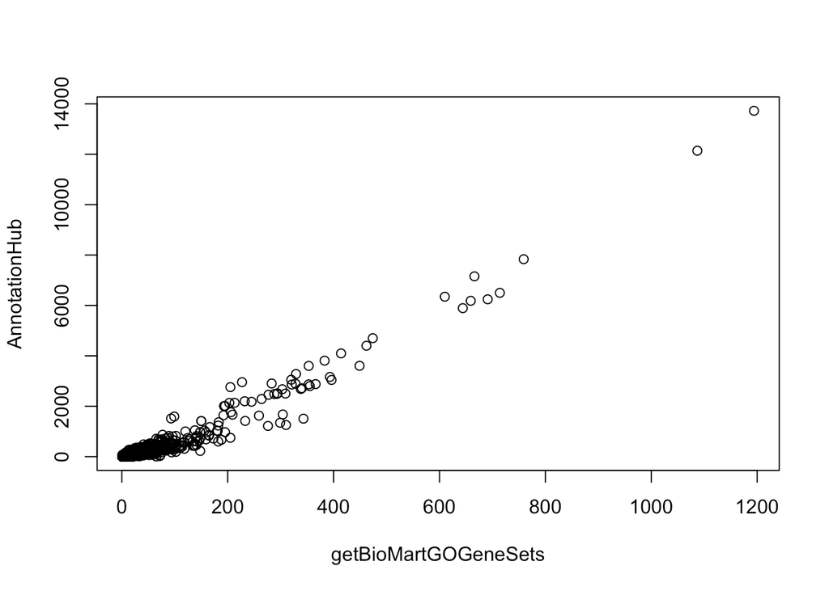

```r
cn = intersect(names(gs1), names(gs2))
n1 = sapply(gs1, length)
n2 = sapply(gs2, length)

plot(n1[cn], n2[cn], xlab = "getBioMartGOGeneSets", ylab = "AnnotationHub")
```

Actually, the GO gene sets from `getBioMartGOGeneSets()`/Ensembl is from an older genome build for dolphin. So it is more suggested to use the data from AnnotationHub/NCBI.